# Comparison of Developed and Developing Countries on Pandemic Response

Curtis Pan

2/28/2022

### Abstract

This report covers the World Health Organization COVID-19 daily reports on the change in cases and deaths in each country. First this report will provide a brief overview of the mean, median of the death rate of countries and territories since the onset of the pandemic. The inferential analysis will conduct a Type II Anova model along with various classification methods such as: logistic regression and k-nearest neighbours, in addition to k-means clustering. The sensitivity analysis will make sure the models fitted are appropriate given the data. Finally in the discussion, I will discuss the findings from my analysis and possible caveats regarding my analysis, as well as future avenues of exploration.

### Background

This breif summarizes findings on the classification of countries, Developed vs. Developing, and their COVID-19 death rates over the course of the pandemic, in order to answer the question whether or not there is a difference in the handling of the pandemic between Developed and Developing countries, by looking at each countries respective death rates and proportion of positive cases.

The COVID-19 data comes directly from the World Heath Organization’s COVID-19 Dashboard, with max cases representing the max total number of cases identified in the country, and death rate comes from dividing the total COVID-19 deaths by the total number of coronavirus cases.The countries listed are also divided by their respective WHO-regions as well. The other variables such as Classification come from the United Nations’ World Economic Situation and Prospects 2022, where countries are classified as Developed, Developing, or In Transition based off a country’s per capita gross national income (GNI), human assets index, and economic and environmental vulnerability index from recommendations from the UN Committeefor Development Policy. The sample used in this study is a subset of the WHO’s COVID-19 Data with the WESP 2022 CLassifications with a primary focus on the more populated end of the countries classified as Developed and Developing. In total this comes to about 113 countries with a popualtion range from 5.4 million to 1.4 billion people. Population data comes from the US Census Bureau and this popualtion was used to calculate the proportion of positive cases to the population in case rate.

```
## # A tibble: 228 × 4
##    Country             max_cases max_deaths death_rate
##    <chr>                   <dbl>      <dbl>      <dbl>
##  1 Afghanistan            176201       7643      4.34
##  2 Albania                272663       3485      1.28
##  3 Algeria                265432       6864      2.59
##  4 American Samoa            555          0      0
##  5 Andorra                 38794        152      0.392
##  6 Angola                  98927       1900      1.92
##  7 Anguilla                 2574          9      0.350
##  8 Antigua and Barbuda      7466        135      1.81
##  9 Argentina             8971432     127187      1.42
## 10 Armenia                422021       8576      2.03
## # … with 218 more rows
```

```
## # A tibble: 6 × 10
##   Country  max_cases max_deaths death_rate X     Classification Doc.Classificat…
##   <chr>        <dbl>      <dbl>      <dbl> <fct> <fct>          <fct>
## 1 Finland     761110       2717      0.357 "Fin… Developed      Developed
## 2 Denmark    2950605       5175      0.175 "Den… Developed      Developed
## 3 Bulgaria   1112699      36098      3.24  "Bul… Developed      Developed
## 4 Switzer…   3058825      12766      0.417 "Swi… Developed      Developed
## 5 Austria    3183997      14568      0.458 "Aus… Developed      Developed
## 6 Hungary    1814362      44653      2.46  "Hun… Developed      Developed
## # … with 3 more variables: Region <fct>, Population..mil. <dbl>,
## #   case_rate <dbl>
```

# Decriptive Analysis

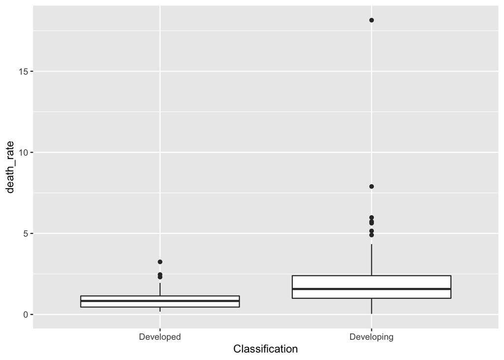

```
## # A tibble: 1 × 1
##   mean_score
##        <dbl>
## 1       1.53
```

```
## # A tibble: 1 × 1
##   mean_score
##        <dbl>
## 1      0.774
```

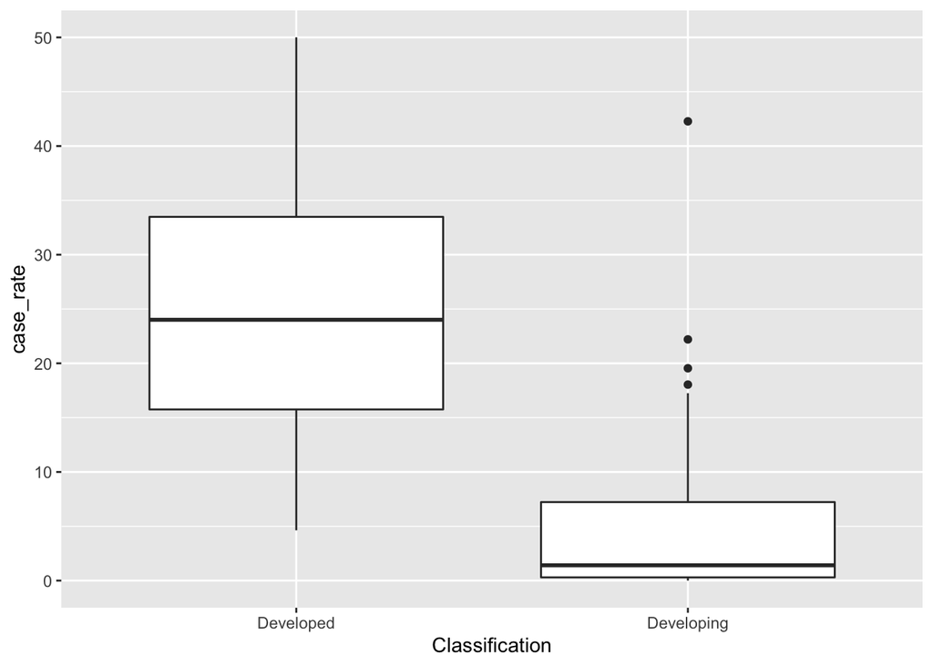

The case rate is signifciantly higher in developed countries vs developing countries.

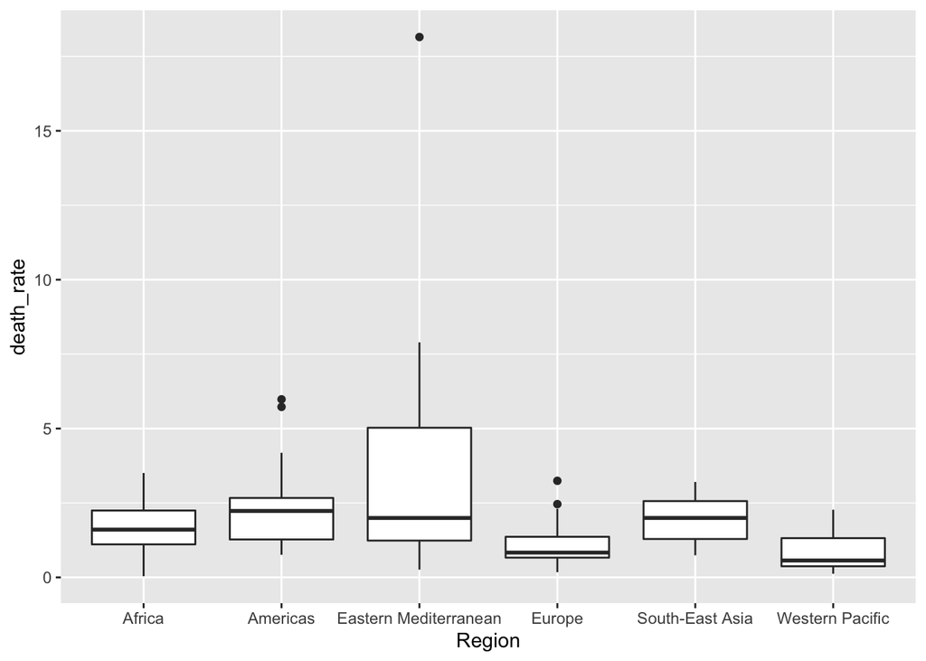

The median death rates of the various WHO regions are displayed and conveys that the Western Pacific and Europe regions have the lowest death rates among the regions. The Eastern Meditteranean region is the biggest outlier with a clear outlier and the largest range out of the other regions.

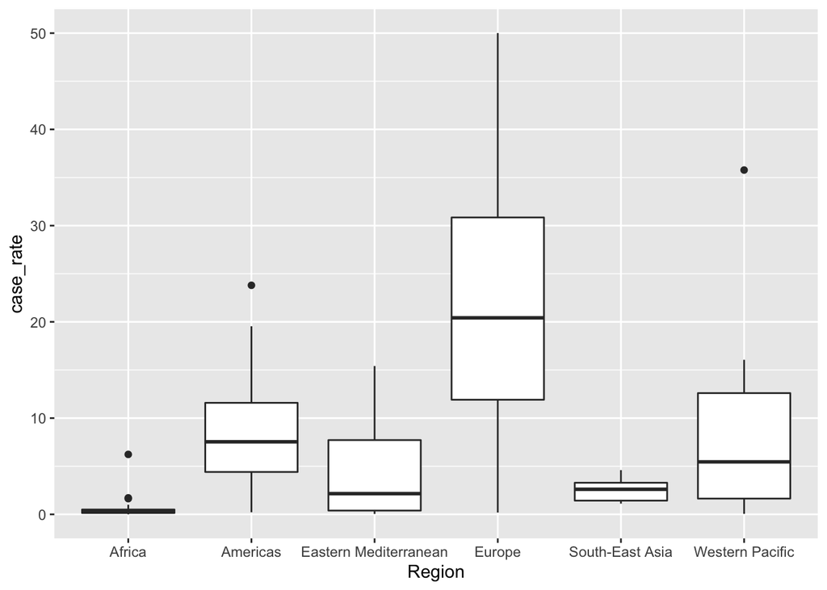

The box plots by region illustrate that Europe, Western Pacific, and the Americas have the highest number of cases globally compared to the other regions.

# Inferential Analysis

### Two-Way ANOVA Model

A Type II, Two-way ANOVA model is appropriate for this data as the factor levels do not contain the same amount of countries per category meaning the study is unbalanced.

In this two-way ANOVA model we assume that there is homoskedasticity, the variance of the mean for each category shoulb be similar for each group being sampled. We also assume that each observation is independent and that the dependent variable follows a normal distribution.

```
## Anova Table (Type II tests)
##
## Response: death_rate
##                 Sum Sq  Df F value   Pr(>F)
## Classification   1.405   1  1.1764 0.280594
## Region          25.749   5  4.3123 0.001322 **
## Residuals      124.199 104
## ---
## Signif. codes:  0 '***' 0.001 '**' 0.01 '*' 0.05 '.' 0.1 ' ' 1
```

Since the ANOVA table iillustrates the p-value for Region is small or lower than a 5% significance level the factor “Region” has a signifcant factor effect on the death rate of a country.

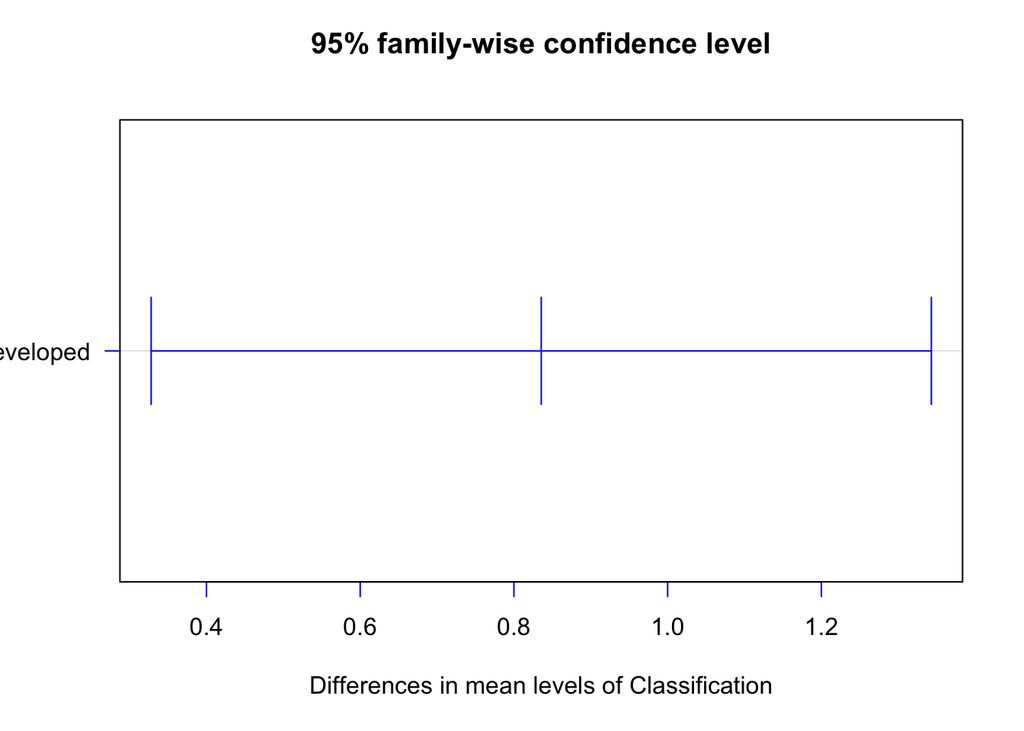

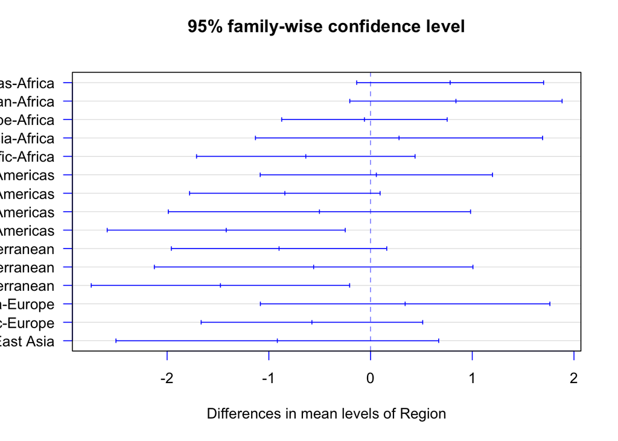

Graphical display for Tukey’s HSD for WHO Region Covid data, with any confidence intervals that do not contain zero meaning they display a difference in the means of each region.

### Logistic Regression

A logistic regression model is appropriate in order to verify whether or not countries would actually match with their classifications if classification was based on death rate and case rate of a country. A training and test set of 80:20 was used for this logistic regression model named train and test respectively.

```
##
## Call:
## glm(formula = Classification ~ death_rate + case_rate + death_rate:case_rate,
##     family = "binomial", data = train)
##
## Deviance Residuals:
##      Min        1Q    Median        3Q       Max
## -2.26684   0.00496   0.08207   0.25905   1.80958
##
## Coefficients:
##                      Estimate Std. Error z value Pr(>|z|)
## (Intercept)           0.82171    1.26489   0.650  0.51593
## death_rate            3.95772    1.68670   2.346  0.01895 *
## case_rate             0.02786    0.06428   0.433  0.66467
## death_rate:case_rate -0.30308    0.11279  -2.687  0.00721 **
## ---
## Signif. codes:  0 '***' 0.001 '**' 0.01 '*' 0.05 '.' 0.1 ' ' 1
##
## (Dispersion parameter for binomial family taken to be 1)
##
##     Null deviance: 84.241  on 89  degrees of freedom
## Residual deviance: 37.102  on 86  degrees of freedom
## AIC: 45.102
##
## Number of Fisher Scoring iterations: 8
```

The estimated parameters here are
$$\hat\alpha = 0.8217076\ ,$$
$$\hat\beta_1 = 3.9577153\ ,$$
$$\hat\beta_2 = 0.0278649\ ,$$
and
$$\hat\beta_3 = -0.3030774\ .$$

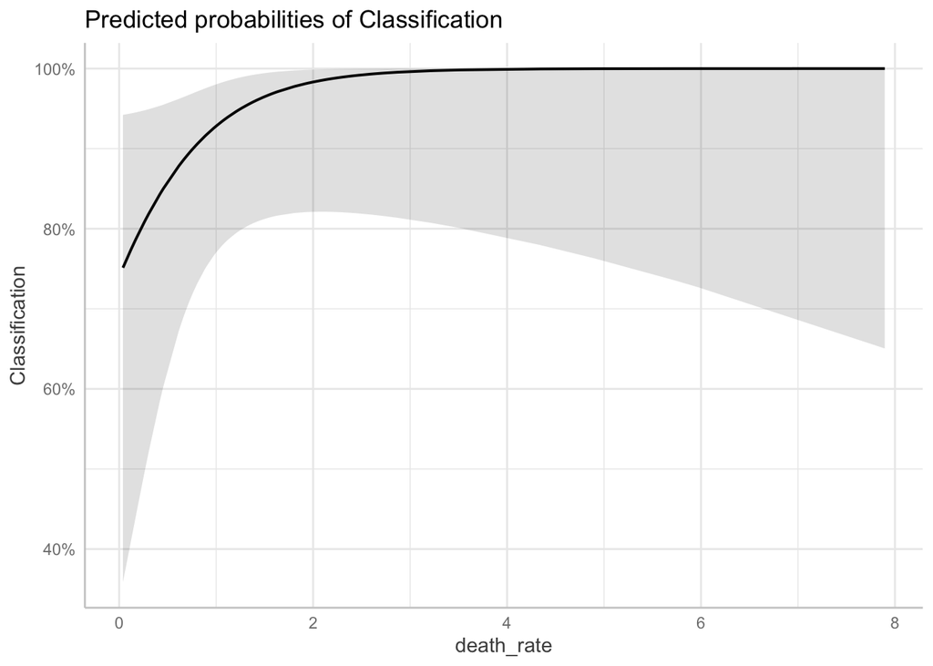

From the logistic regression model, holding case rate constant, death rate as a predictor for probability of a country being classified as “Developing” increases as death rate increases.

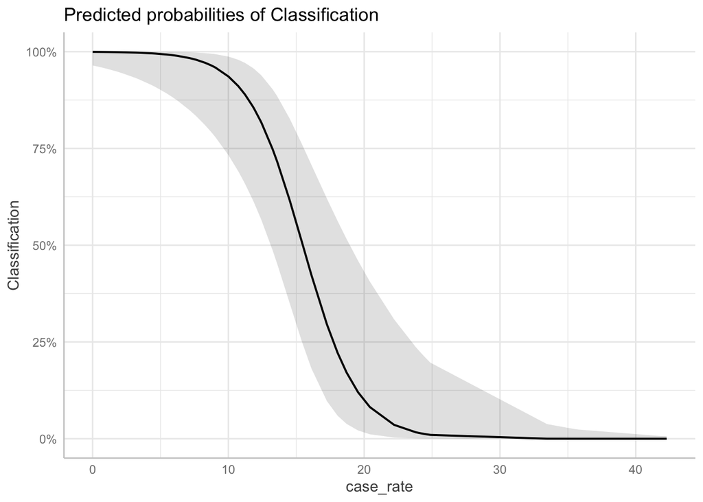

In regards to case rate as a predictor, holding death rate constant, it seems that a country is less likely to be classified as “Developing” as the proportion of people contracting COVID-19 increase, more likely to be classified as “Developed” due to that factor.

```
##             predicted
## true         FALSE TRUE
##   Developed      5    2
##   Developing     0   16
```

```
## [1] 0.08695652
```

The misclassification error rate of this logistic regression model 8.69% for the classification of countries as “Developed” and “Developing.”

### Wald Test for Logistic Regression

$H_0$: the coefficient of the predictor equals zero

$H_a$: the coefficient of the predictor does not equal zero

From the logistic regression output, the predictors, deaht_rate and the interaction effect between death rate and case rate, reject the null hypothesis at the significance level of 5%. Concluding that those predictors are significant to the model and that case rate as a predictor is not as significant to the model and could be removed according to Wald’s test.

### K-nearest neighbors

Another classification method is to use K-nearest neighbours, here looking at the 10 nearest neighbours of countries with the most similar characteristics.

```
##  [1] Developing Developing Developing Developing Developing Developing
##  [7] Developing Developing Developing Developing Developing Developing
## [13] Developing Developing Developing Developing Developing Developing
## [19] Developing Developing Developing Developing Developing
## Levels: Developed Developing
```

```
##             predicted
## true         Developed Developing
##   Developed          0          7
##   Developing         0         16
```

```
## [1] 0.3043478
```

### K-means Clustering

By specifying two clusters, one for Developed and Developing, we can classify the data points based on their average distance betwween each observation and the center of the cluster into Developed and Developing based on our predictors death rate and case rate.

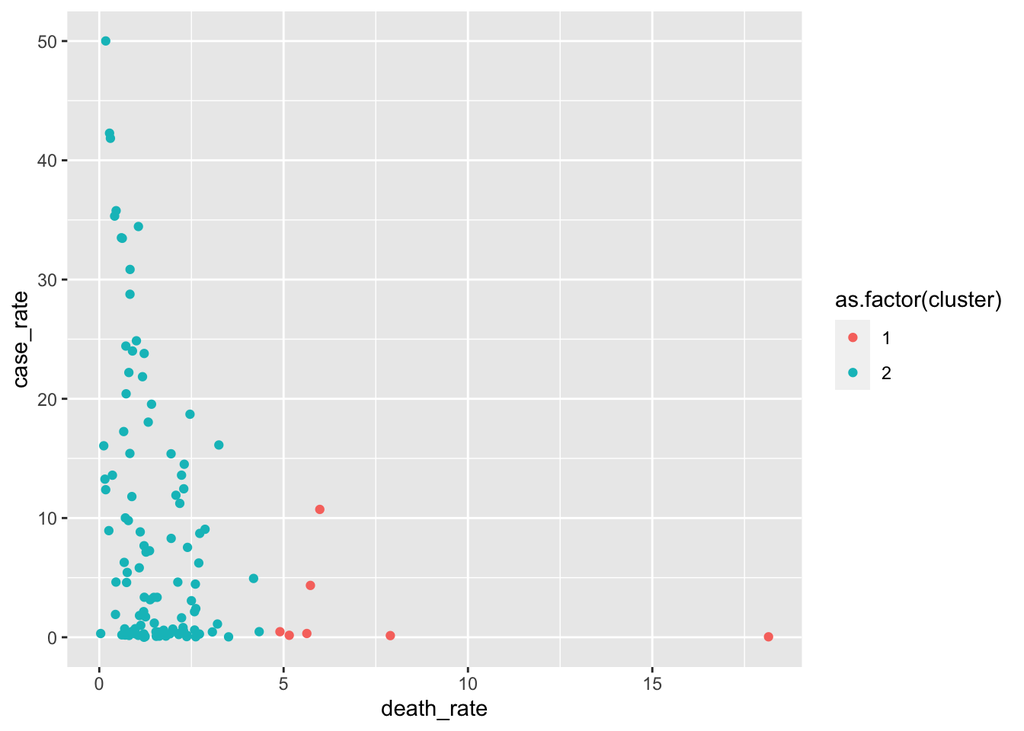

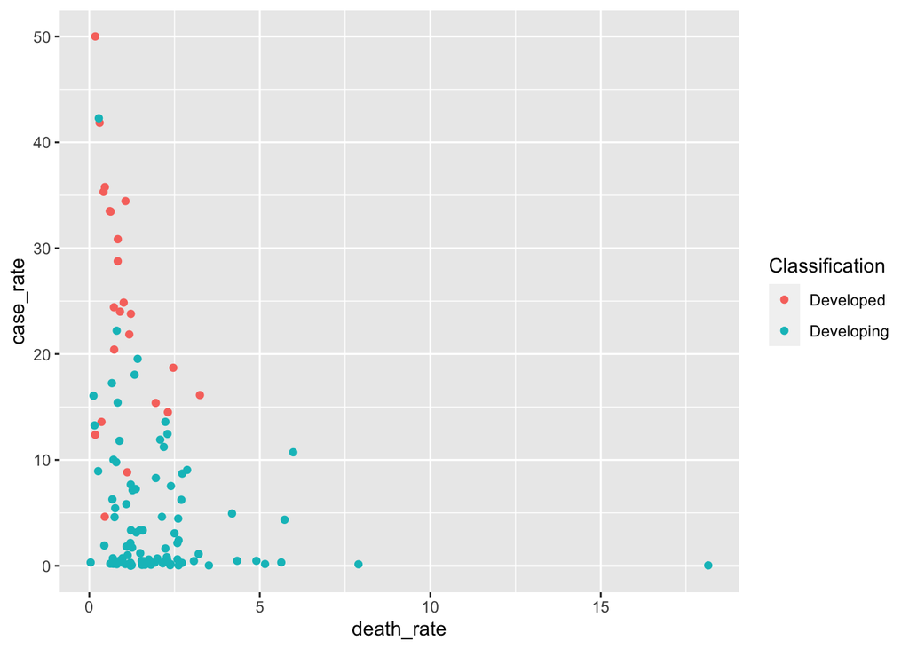

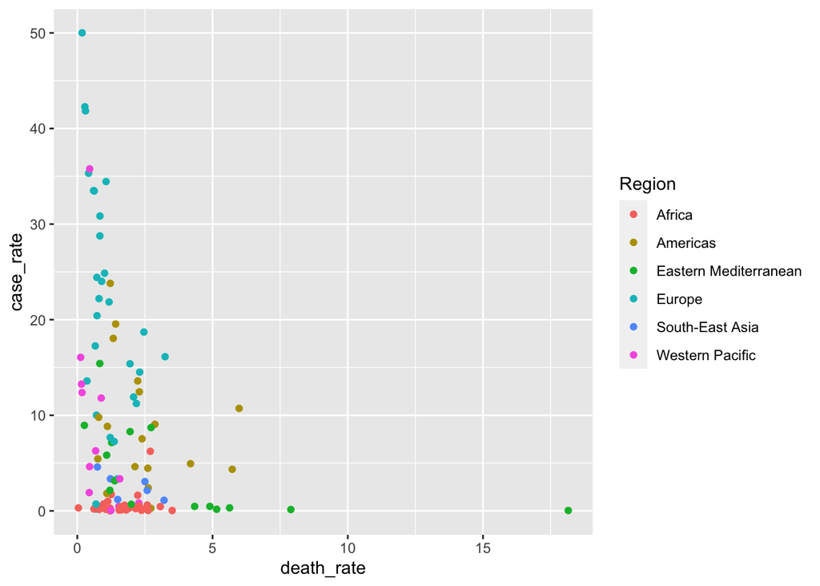

# Sensitivity Analysis

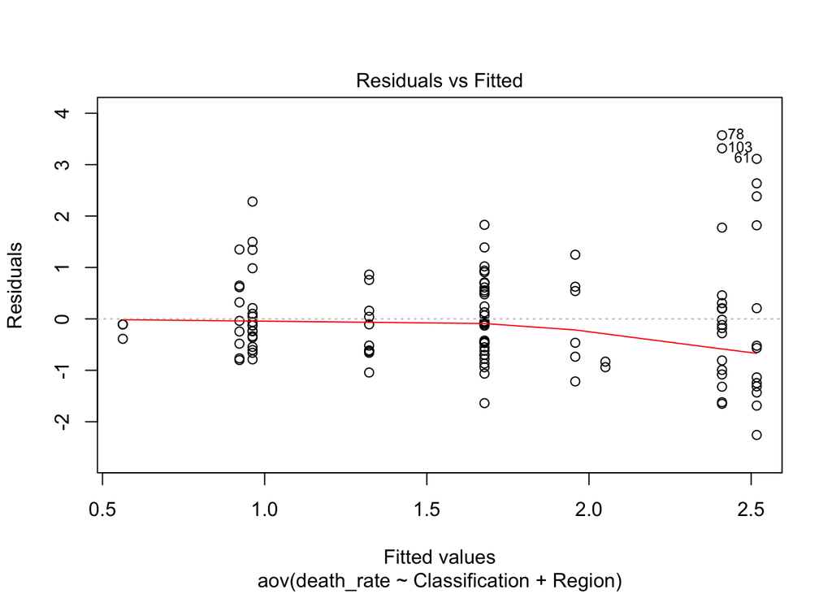

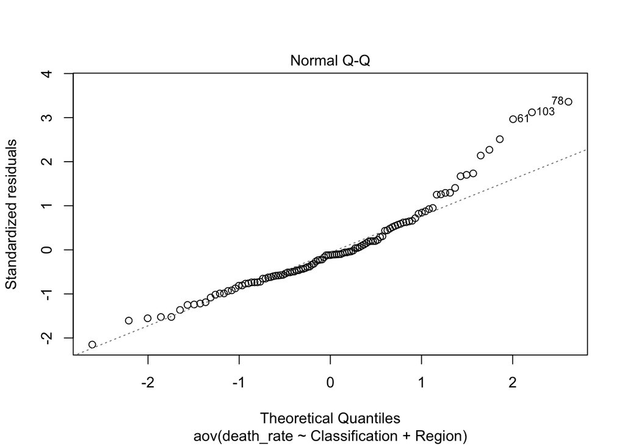

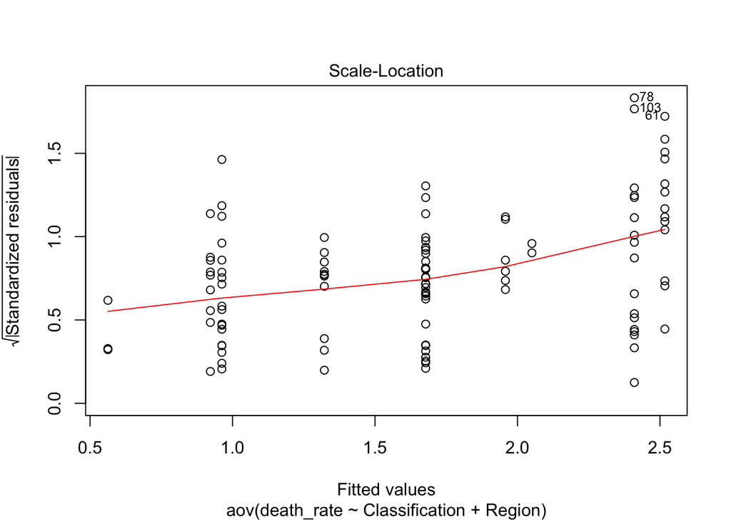

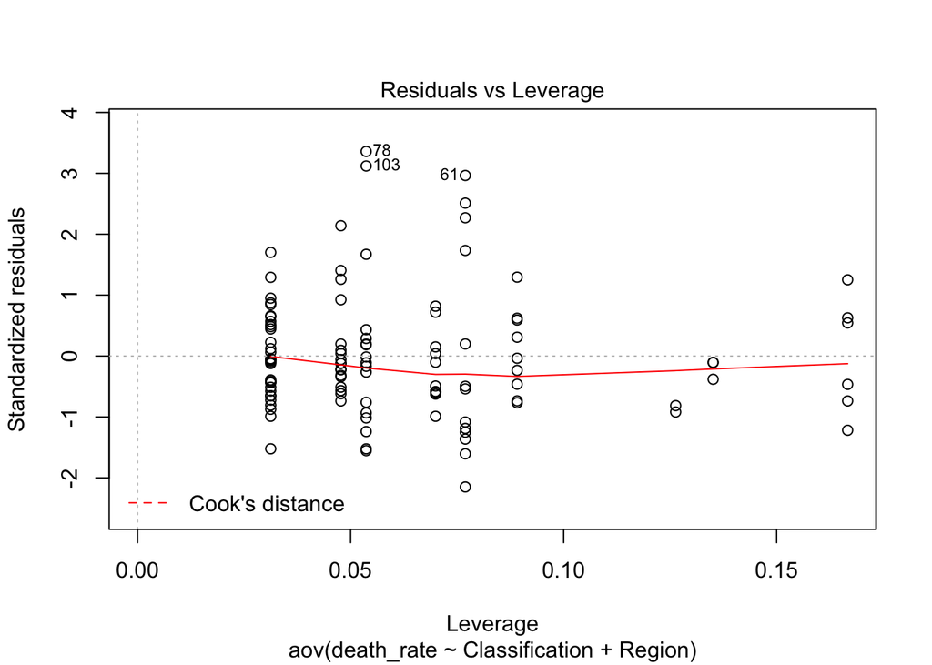

###Levene’s test

$H_0$: variances of the population from the samples are equal

$H_a$: variances of the population from the samples are not equal

```
## Levene's Test for Homogeneity of Variance (center = median)
##        Df F value   Pr(>F)
## group   8  2.9596 0.005044 **
##       104
## ---
## Signif. codes:  0 '***' 0.001 '**' 0.01 '*' 0.05 '.' 0.1 ' ' 1
```

The null hypothesis is rejected at the 5% significance level as the p-value of Leven’s test is less than the significance level, and conclude that there is a difference between the variances of the population or there is not homoskedasticity.

# Discussion

In this report, I looked at multiple methods to compare the pandemic response between developed and developing countries by comparing their death rates and case rates. Through the Logistic Regression, it seems that countries with a high death rate are more likely to be classified as developing countries and that higher death rates are associated with developing countries moreso than developed. On the other hand, a higher case rate illustrates the opposite, as developed countries have a lower or similar death rate to typical developing countries but have a significantly higher case rate. This indicates that we could classify countries as developed based on their tendency to have a lower death rate but higher case rate and developing based on a higher death rate but lower case rate.

However a potential source of error or misclassification could stem from the fact that the case rate is derived from the total number of positive cases in the country over the two years of the pandemic; however, this does not account for the fact that people can test positive multiple times. A better predictor would have compared the number of tests per day and found the positivty rate of those tests done in each country as a better predictor if looking to use coronavirus cases as a metric of classifying countries compared to death rate. In addition, by predicting on percentage of tests being positive, the data would better reflect the current nature that European countries and American countries perform more coronavirus tests compared to the other regions, which resulted in higher case rates for those regions in this report. By utilizing testing positivity data it could help mitigate these caveats in future studies on country performance regarding the pandemic and the differences between developed and developing countries.

Another caveat or source of error are outliers, in this case countries with a very high death rate as seen in the clustering can easily skew the data and classification results in logistic regression and k-nearest neighbor, and k-means. A high death rate can also be from external causes unrelated to COVID-19 such as war, countries like Yemen are currently in a conflict and have relected high coronavirus deaths; however, without verification it is hard to confirm whether or not these numbers are accurate given the low case rate percentage. In the case of clustering an outlier can increase the distance from the center of a cluster to other data points and cause less points to be classified with them in this case. In logistic and k-neearest neighbors an outlier can make a predictor seem to have higher likelihood ratios for a certain designation and skew the classification of data points, making the predictor seem more impactful to the classification than it actually is.

For future projects it would help to expand on testing data and vaccination data as well to truly indicate differences between countries and their handling of the pandemic, as well as a comparison for the first year fo the pandemic vs. the second year to see how countries have adapted the last couple of years throughout the different coroanvirus waves.

# Acknowledgement

I worked on this project with my teammate Alexa Aguirre, with consultation from our teaching assistant, Xiawei Wang.

# Reference

U.S. and World Population Clock. United States Census Bureau. (n.d.). Retrieved February 28, 2022, from https://www.census.gov/popclock/world

World Health Organization. (n.d.). Who coronavirus (COVID-19) dashboard. World Health Organization. Retrieved February 28, 2022, from https://covid19.who.int/

Zhenmin, L., Barcena, A., Grynspan, R., Alisjahbana, A. S., Songwe, V., Dashti, R., & Algayerova, O. (2022, January 13). World Economic Situation and Prospects 2022. Retrieved February 20, 2022, from https://www.un.org/development/desa/dpad/wp-content/uploads/sites/45/publication/WESP2022_web.pdf